# mid_term

```python
%matplotlib inline
from google.colab import files
import io
import numpy as np
import pandas as pd
from matplotlib import pyplot as plt
import seaborn as sns
from sklearn.model_selection import train_test_split
from sklearn.model_selection import StratifiedKFold
from sklearn.preprocessing import StandardScaler
from sklearn.neighbors import KNeighborsClassifier
from sklearn.linear_model import LogisticRegression
from sklearn.svm import SVC
from sklearn.ensemble import RandomForestClassifier
from sklearn.model_selection import GridSearchCV
from sklearn.model_selection import cross_val_score
```

In answering each of the following questions please include

- The question as a markdown header in your Jupyter notebook
- The raw code that you used to generate any results, tables, or figures, and
- The top ten or fewer rows of the data-frame (do not include more than ten rows for any table in your report)

Include any plots or figures generated from your code as well.

Use the spam dataset and variable descriptions in the files/Mid-Term Exam folder of the course website to answer the following questions.

# 1. Import the spam dataset and print the first six rows.

```python
# Load file into Google Drive so Colab can use this (wont work outside colab)
uploaded = files.upload()
```

Upload widget is only available when the cell has been executed in the current browser session. Please rerun this cell to enable.

```
Saving spam_dataset.csv to spam_dataset.csv
```

```python
# Import data from Google Drive
df_spam = pd.read_csv(io.StringIO(uploaded['spam_dataset.csv'].decode('utf-8')))
df_spam.head(6)
```

|  | word_freq_make: | word_freq_address: | word_freq_all: | word_freq_3d: | word_freq_our: | word_freq_over: | word_freq_remove: | word_freq_internet: | word_freq_order: | word_freq_mail: | word_freq_receive: | word_freq_will: | word_freq_people: | word_freq_report: | word_freq_addresses: | word_freq_free: | word_freq_business: | word_freq_email: | word_freq_you: | word_freq_credit: | word_freq_your: | word_freq_font: | word_freq_000: | word_freq_money: | word_freq_hp: | word_freq_hpl: | word_freq_george: | word_freq_650: | word_freq_lab: | … |
| --- | --- | --- | --- | --- | --- | --- | --- | --- | --- | --- | --- | --- | --- | --- | --- | --- | --- | --- | --- | --- | --- | --- | --- | --- | --- | --- | --- | --- | --- | --- |
| 0 | 0.00 | 0.64 | 0.64 | 0.0 | 0.32 | 0.00 | 0.00 | 0.00 | 0.00 | 0.00 | 0.00 | 0.64 | 0.00 | 0.00 | 0.00 | 0.32 | 0.00 | 1.29 | 1.93 | 0.00 | 0.96 | 0.0 | 0.00 | 0.00 | 0.0 | 0.0 | 0.0 | 0.0 | 0.0 | … |
| 1 | 0.21 | 0.28 | 0.50 | 0.0 | 0.14 | 0.28 | 0.21 | 0.07 | 0.00 | 0.94 | 0.21 | 0.79 | 0.65 | 0.21 | 0.14 | 0.14 | 0.07 | 0.28 | 3.47 | 0.00 | 1.59 | 0.0 | 0.43 | 0.43 | 0.0 | 0.0 | 0.0 | 0.0 | 0.0 | … |
| 2 | 0.06 | 0.00 | 0.71 | 0.0 | 1.23 | 0.19 | 0.19 | 0.12 | 0.64 | 0.25 | 0.38 | 0.45 | 0.12 | 0.00 | 1.75 | 0.06 | 0.06 | 1.03 | 1.36 | 0.32 | 0.51 | 0.0 | 1.16 | 0.06 | 0.0 | 0.0 | 0.0 | 0.0 | 0.0 | … |
| 3 | 0.00 | 0.00 | 0.00 | 0.0 | 0.63 | 0.00 | 0.31 | 0.63 | 0.31 | 0.63 | 0.31 | 0.31 | 0.31 | 0.00 | 0.00 | 0.31 | 0.00 | 0.00 | 3.18 | 0.00 | 0.31 | 0.0 | 0.00 | 0.00 | 0.0 | 0.0 | 0.0 | 0.0 | 0.0 | … |
| 4 | 0.00 | 0.00 | 0.00 | 0.0 | 0.63 | 0.00 | 0.31 | 0.63 | 0.31 | 0.63 | 0.31 | 0.31 | 0.31 | 0.00 | 0.00 | 0.31 | 0.00 | 0.00 | 3.18 | 0.00 | 0.31 | 0.0 | 0.00 | 0.00 | 0.0 | 0.0 | 0.0 | 0.0 | 0.0 | … |
| 5 | 0.00 | 0.00 | 0.00 | 0.0 | 1.85 | 0.00 | 0.00 | 1.85 | 0.00 | 0.00 | 0.00 | 0.00 | 0.00 | 0.00 | 0.00 | 0.00 | 0.00 | 0.00 | 0.00 | 0.00 | 0.00 | 0.0 | 0.00 | 0.00 | 0.0 | 0.0 | 0.0 | 0.0 | 0.0 | … |

# 2. Read through the documentation of the original dataset [here](http://archive.ics.uci.edu/ml/machine-learning-databases/spambase/spambase.names). The dependent variable is "spam" where one indicates that an email is spam and zero otherwise. Which three variables in the dataset do you think will be important predictors in a model of spam? Why?

## Response 2.0. Describe the data

The dataset contains 4601 entries (emails), with 57 features and 1 target variable.

The target, `spam`, is a binary variable. 1 indicates that a email was considered spam. 0 indicates that an email was considered not spam.

All the features are continuous variables.

- 48 of these are word proportions for the given word in that feature (a percentage)
- 6 indicate character proportions for the given character in that feature (a percentage)
- The average length of uninterrupted captal letters
- Longest length of uninterrupted capital letters
- Total length of uninterrupted sequences of capital letters

Will take the following approach to the rest of the question:

1. Qualitative inspection of features
2. Visualisation of features in relation to the target
3. Overall assessment of potential feature importance

## Response: 2.1. Qualitative inspection of features

Features related to offers would probably be spam. These are `word_freq_money`, `word_freq_free`, `char_freq_$`. A long run of caps characters usually also indicates some sort of attention grabbing spam email, so `capital_run_length_longest` should also be important.

Of these, if I had to pick 3, I'd pick `word_freq_money`, `word_freq_free`, and `capital_run_length_longest`. High frequency of $ might be a spam offer, but could also be related to bills or work emails with tables full of money values.

## Response: 2.2. Visualisation of features in relation to the target

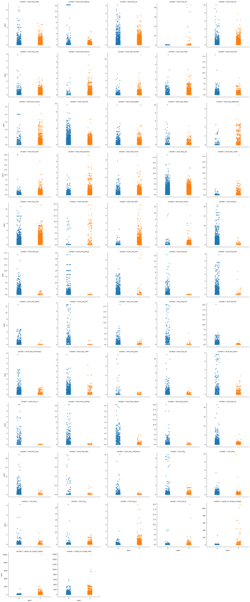

```python
df_spam_long = pd.melt(df_spam, id_vars= 'spam')

g = sns.catplot(x='spam',
                y = 'value',
                col = 'variable',
                data = df_spam_long,
                col_wrap = 5,
                sharey = False)
```

The plots above show us that instead of fixating on the features that will tend to have higher values for spam emails, features that will have higher values for non-spam but low values for spam may also be important features.

These include `word_freq_hp` and `word_freq_hpl` (handphone number?), and work related features like `word_freq meeting` and `word_freq_project`.

## Response: 2.3. Overall assessment of potential feature importance

While the intuition about offers in the qualitative assessment seems to be right - there seems to be some difference between spam and not spam for money and attention grabbing related features like `char_freq_$` and `word_freq_000` (for all the CONGRATULATIONS YOU ARE OUR 1000000000th CUSTOMER spam emails).

However, the features I had picked out earlier, `word_freq_money`, `word_freq_free`, and `capital_run_length_longest`, didn't appear to have a large difference in values between spam and not-spam emails. This might have to do with people using the word "free" in emails in asking for availability "are you free" instead of providing offers, "money" coming up in work emails, and LONG CAPS MESSAGES IN WORK EMAILS TO GRAB YOUR ATTENTION AND SAY LOOK HERE THIS IS IMPORTANT. Given that there are credible reasons for these features to be affected in different ways by spam and non-spam, with the same result on word frequency or capital run length, they are probably not good features to use.

The visualisation also showed that we could look at features that would be higher in non-spam vs spam emails, rather than just higher in spam vs non-spam emails. Boring work-related features like `word_freq meeting` and `word_freq_project` are unlikely to show up in spam (they're precisely the words that will not grab your attention) and would be good features to use.

Going on these ideas of attention grabbing related features and boring turn-off features, I would pick the following 6 (first 3 for the next few questions, 4-6 for qn 12-13).

1. `word_freq_meeting` (boring work feature)
2. `word_freq_project` (boring work feature)
3. `word_freq_000` (ATTENTION GRABBING FEATURE)
4. `word_freq_labs` (boring work feature)
5. `char_freq_$` (ATTENTION GRABBING FEATURE)
6. `word_freq_415`(boring area code from SF Bay area, probably from work - It's a HP dataset. Spam is supposed to get your phone number, not give you one)

# 3. Visualize the univariate distribution of each of the variables in the previous question.

1. `word_freq_meeting`
2. `word_freq_project`
3. `word_freq_000`

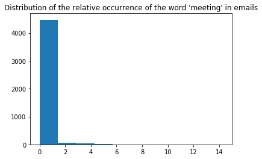

```python
plt.figure()
plt.hist(df_spam['word_freq_meeting:'], bins = 10)
plt.title("Distribution of the relative occurrence of the word 'meeting' in emails")
plt.show()
```

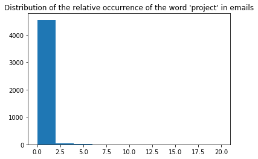

```python
plt.figure()
plt.hist(df_spam['word_freq_project:'], bins = 10)
plt.title("Distribution of the relative occurrence of the word 'project' in emails")
plt.show()
```

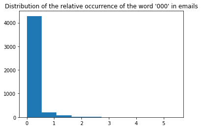

```python
plt.figure()
plt.hist(df_spam['word_freq_000:'], bins = 10)
plt.title("Distribution of the relative occurrence of the word '000' in emails")
plt.show()
```

# 4. Name each of the supervised learning models that we have learned thus far that are used to predict dependent variables like "spam".

`spam` is a categorical outcome variable.

Supervised models learned so far to predict categorical outcome variables:

1. K-Nearest Neighbours
2. Logistic Regression
3. Penalised versions of logistic regression
   - L1 regularisation
   - L2 regularisation
   - L1 + L2 regularisation (in readings)
4. Support Vector Machines (for classification)
5. Decision Trees (for classification)
6. Bagged Trees
7. Random Forest
8. Boosted models using Decision Trees (in readings)
   - AdaBoost
   - Gradient Boosting

# 5. Describe the importance of training and test data. Why do we separate data into these subsets?

Supervised learning models all aim to generate a predicted outcome of interest, given specific values of input features. Ideally, this predicted outcome should be as close to the true outcome as possible. Hence, the models aim to develop a function of the input features to the outcome variable that approximates their true relation. They do this, in differing ways, by relating features to outcome in training data provided to the model during a training phase.

There is an assumption inherent in approximating the true relation between features and outcome by relating features to outcome in training data. It is assumed that the relations that the model finds from the training data, reflected in its resultant function of features to produce a predicted outcome, is also true for new data that the model was not trained on.

This assumption is not necessarily true. The model may have discovered relationships between features and outcome which are specific to the data it was trained on, and do not exist in other data. These specific relations may occur by chance, or by a systematic artefact of the training data that is not present in other datasets. In these situations, the model may develop a function relating features to outcome based on relations in the training data that do not exist in other data. As a result, the model performs poorly on data that is different from its training set. This reduces the practical utility of the model as a predictive tool.

Splitting the data into training and test data is one way to check the assumption that the relations between features and outcome learned by the model from the training data is not specific to the training data. When the available data is split, the model is trained only on the training data, and is then used to predict the test data. The performance of the model on the test data can be used to see if the functon developed by the model on its training data was specific to relations existing only within the training dataset. If there was good model performance on the training data but poor model performance on the test data, one should be skeptical of the model's ability to approximate the true relationship between feature and outcome, rather than specific aspects of the training data. Ideally, a model should perform just as well on test data as it does on data it was trained on.

# 6. What is k-fold cross validation and what do we use it for?

K-Fold Cross Validation is a resampling technique used as one way to evaluate model performance. With small datasets, it may be the only model evaluation technique used, whereas in larger datasets, it may be conducted alongside using a separate test set for further evaluation.

K-fold Cross Validation follows the following steps:

1. The training data is split into k sets of roughly equal size using simple random sampling.
2. A model is trained on all but one of the k sets. The set that is not used for training is known as the 'hold-out set'.
3. The model is used to predict the outcome variable of the hold-out set.
4. The model's predictions are compared to the true outcome values in the hold-out set. The discrepancy between predicted and true outcome values indicate model performnance, and is summarised using model performance metrics such as:
   - For classification tasks: Accuracy, area under the ROC curve (AUC)
   - For regression tasks: r-squared, root mean squared error
5. Steps 2-4 are repeated using the same performance metric, but a different set is used as the hold-out set. This is repeated until every set has been used as the hold out set exactly once. This means a total of k models are trained.
6. The model performance metrics from each of the k models is the output of K-fold cross validation, and indicates how well the model has performed in predicting data that it was not trained on. These may be summarised using the mean and variance to understand overall model performance and consistency.

K-fold Cross Validation is favoured for model evaluation since

1. Evaluation is accomplished using all the training data. At the end of K-fold Cross Validation, all cases in the training data have been used for model training k-1 times, and for prediction 1 time.
2. In training several models and generating several values for model performance, K-fold cross validation allows an evaluation of the variation of model performance.

As a model evaluation technique, K-fold cross validation is used in machine learning to:

1. Find the optimal values for model hyperparameters to use for the final model. Here, K-fold Cross Validation is used to evaluate models using different values for model hyperparameters. The values used for the model that performs best in K-fold Cross Validation are typically chosen for the final model.
2. Find the optimal model type to use. K-fold Cross Validation can be used to evaluate competing types of models (e.g. SVM vs Random Forest). Typically the model type that performs best in K-fold Cross validation is chosen.

# 7. How is k-fold cross validation different from stratified k-fold cross validation?

Simple K-fold Cross Validation splits the available training data into K sets using simple random sampling, whereas Stratified K-fold Cross Validation instead uses stratified random sampling to split the training data into K sets. Because of the nature of stratified random sampling, Stratified K-fold Cross Validation can only be used when the outcome variable is categorical, whereas simple K-fold Cross Validation can be used for both continuous and cateogorical outcome variables.

When using simple random sampling, every case in the training data is selected completely by random to be placed in a given set. In the case of a categorical outcome variable, this means that the proportion of classes within each set could differ between sets.

For instance, take a training dataset with 100 cases, 60 having an outcome variable class of 1 and 40 having an outcome variable class of 0. If K = 4, the first set may contain an 15 cases with an outcome variable class of 1, and 10 cases with an outcome variable class of 0. The second set may have 20 cases with an outcome variable class of 1, and 5 with an outcome variable class of 0, and so on. The ratio of the number of cases in class 1 to class 0 in the first set is not equal to the same ratio in the second set.

Instead, when using stratified random sampling, cases are first divided based on their outcome variable class (hence by Stratified K-fold Cross Validation can only be used when the outcome variable is categorical). It is only within these outcome variable classes that cases are completely randomly selected to be placed in a given set. This means that the proportion of classes within each set is equal between sets, and mirrors the proportion of classes in the full training data. Slight deviations may exist only if numbers are not cleanly divisible (e.g. splitting 100 cases into 6 sets).

For instance, using the same example above with K = 4, Stratified K-fold Cross validation will first split the 100 cases into the 60 with outcome variable class 1 and 40 with outcome variable class 0. These will then be randomly assigned to each of the K sets, such that each set has 15 cases with outcome variable class 1 and 10 cases with outcome variable class 0.

# 8. Choose one model from question four. Split the data into training and test subsets. Build a model with the three variables in the dataset that you think will be good predictors of "spam".

```python
## Setup needed objects

# Split data into features and outcome
df_spam_X_3 = df_spam[['word_freq_meeting:',
                      'word_freq_project:',
                      'word_freq_000:']]
df_spam_y = df_spam['spam']

# Cross validation object
cv_obj = StratifiedKFold(n_splits= 10, shuffle = True, random_state= 123)

# Scaling object
scaler = StandardScaler()
```

## Model Chosen - K Nearest Neighbours

```python
knn = KNeighborsClassifier()
```

```python
# Split data
X_train_3_spam, X_test_3_spam, y_train_spam, y_test_spam = train_test_split(df_spam_X_3,
                                                                            df_spam_y,
                                                                            test_size = 0.2,
                                                                            random_state = 123
                                                                            )
```

```python
# Scaling data
scaler.fit(X_train_3_spam)
X_train_3_spam_scaled = scaler.transform(X_train_3_spam)
X_test_3_spam_scaled = scaler.transform(X_test_3_spam)
```

```python
# Grid Search CV
sqrt_n = int(round(np.sqrt(df_spam_X_3.shape[0])))

param_grid_knn = {'n_neighbors': np.arange(1, sqrt_n, 2),
                  'weights': ['uniform', 'distance'],
                  'p': [1, 2]
                  }

knn_grid = GridSearchCV(knn,
                        param_grid_knn,
                        scoring='accuracy',
                        cv = cv_obj
                        )
knn_grid.fit(X_train_3_spam_scaled, y_train_spam)
```

```
GridSearchCV(cv=StratifiedKFold(n_splits=10, random_state=123, shuffle=True),
             error_score=nan,
             estimator=KNeighborsClassifier(algorithm='auto', leaf_size=30,
                                            metric='minkowski',
                                            metric_params=None, n_jobs=None,
                                            n_neighbors=5, p=2,
                                            weights='uniform'),
             iid='deprecated', n_jobs=None,
             param_grid={'n_neighbors': array([ 1,  3,  5,  7,  9, 11, 13, 15, 17, 19, 21, 23, 25, 27, 29, 31, 33,
       35, 37, 39, 41, 43, 45, 47, 49, 51, 53, 55, 57, 59, 61, 63, 65, 67]),
                         'p': [1, 2], 'weights': ['uniform', 'distance']},
             pre_dispatch='2*n_jobs', refit=True, return_train_score=False,
             scoring='accuracy', verbose=0)
```

```python
print("k Nearest Neighbours best score: {:.4f}"\
      .format(knn_grid.best_score_))
print("k Nearest Neighbours best params: {}"\
      .format(knn_grid.best_params_))
```

```
k Nearest Neighbours best score: 0.7207
k Nearest Neighbours best params: {'n_neighbors': 65, 'p': 2, 'weights': 'uniform'}
```

## 8.1. Describe why you chose any particular parameters for your model (e.g.- if you used KNN how did you decide to choose a specific value for k).

The value of a model parameter that is best for prediction depends on the data. One way of finding the best value for a model hyperparameter for a given dataset is to perform a grid search. This is an exhaustive search through a specified set of possible parameter values. A model is trained on each possible combination of parameters and scored using a model evaluation metric. All the models are then compared, and the parameter combination chosen to use in the final model is the one that yielded the best performance on the model evaluation metric within the gridsearch.

In this case, K-Nearest Neighbours was chosen as the model, with 3 main model parameters that need to be defined

- The number of neighbours - `n_neighbors`
  - In general, odd numbers of neighbours are used to prevent ties in classification when using uniform weighting
  - I also read online that a good rule of thumb would be to have k <= sqrt(n)
- The power parameter for the distance metric - `p`
  - 1 uses Manhattan distance
  - 2 uses Euclidean distance
- The weight function used in prediction - `weights`
  - uniform weights each neighbour equally
  - distance weights points by the inverse of their distance

A gridsearch was used to iterate all these possible parameters, with the number of neighbours from 1-67, the two different types of distance metrics, and weight functions. The final parameters chosen were those that yielded the best accuracy score of all the models tested in the gridsearch, evaluated using stratified 10-fold cross validation. These were:

- `n_neighbors` - 65
- `p` - 2 (Euclidean distance)
- `weights` - uniform

## 8.2. Run the model and evaluate prediction error in two ways:

1. On test data directly and
2. Using k-fold cross-validation

```python
knn_3_best = KNeighborsClassifier(n_neighbors = 65, p = 2, weights = 'uniform')
knn_3_best.fit(X_train_3_spam_scaled, y_train_spam)
```

```
KNeighborsClassifier(algorithm='auto', leaf_size=30, metric='minkowski',
                     metric_params=None, n_jobs=None, n_neighbors=65, p=2,
                     weights='uniform')
```

```python
# Test on test data
knn_3_best.score(X_test_3_spam_scaled, y_test_spam)
```

```
0.7328990228013029
```

```python
# Test using K-fold Cross validation
cross_val_score(knn_3_best,
                X_train_3_spam_scaled,
                y_train_spam,
                cv = cv_obj,
                scoring='accuracy').mean()
```

```
0.7206521739130436
```

# 9. Choose a second model from question four. Using the same three variables in the dataset that you think will be good predictors of "spam"...

## Model Chosen - Logistic Regression

```python
log_reg = LogisticRegression()
```

```python
%%capture
# Use the %%capture magic command to suppress output from this cell - there are
# a lot of models that yield errors because of the incompatibility of the
# l1_ratio parameter with any regularisation form other than elastic net.

# Grid Search CV
param_grid_log_reg = {'penalty': ['l1', 'l2', 'none', 'elasticnet'],
                      'C': [0.0001, 0.001, 0.01, 0.1, 1, 10, 100, 1000, 10000],
                      'solver': ['saga'],
                      'l1_ratio': np.arange(0.1, 1.1, 0.1),
                      'max_iter': [10000]
                      }
# Choose saga solver because it supports all specified forms of regularisation
log_reg_grid = GridSearchCV(log_reg,
                            param_grid_log_reg,
                            scoring='accuracy',
                            cv = cv_obj
                            )
log_reg_grid.fit(X_train_3_spam_scaled, y_train_spam)
```

```python
print("Logistic Regression best score: {:.4f}"\
      .format(log_reg_grid.best_score_))
print("Logistic Regression best params: {}"\
      .format(log_reg_grid.best_params_))
```

```
Logistic Regression best score: 0.7174
Logistic Regression best params: {'C': 0.0001, 'l1_ratio': 0.1, 'max_iter': 10000, 'penalty': 'none', 'solver': 'saga'}
```

## 9.1.Describe why you chose any particular parameters for your model (e.g.- if you used KNN how did you decide to choose a specific value for k).

As mentioned above, the value of a model parameter that is best for prediction depends on the data. One way of finding the best value for a model hyperparameter for a given dataset is to perform a grid search (as explained above).

In this case, Logistic Regression was chosen as the model, with 4 main model parameters that need to be defined

- The type of regularisation to be used - `penalty`
  - L1 penalises the binomial regression function that logistic regression tries to maximise using the sum of the absolute coefficients of features
  - L2 penalises the binomial regression function that logistic regression tries to maximise using the sum of the squared coefficients of features
  - Elastic net uses a combination of L1 and L2 penalties
  - None indicates an unpenalised model
- The regularisation strength - `C`
  - Smaller values specify stronger regularisation. A high value of C approximates unpenalised logistic regression
  - IMLP advises that C is usually searched for on a logarithmic scale, which is done here, on a log10 scale from 0.0001 to 10000
- The ratio of L1 to L2 regularisation applied when elastic net regularisation is used - `l1_ratio`
  - Because elastic net regularisation combines L1 and L2 regularisation, this parameter specifies how much weight to give to each.

Aside from these, a few other parameters were defined, but not iterated over

- The maximum number of iterations for solvers to converge - `max_iter`
  - This needs to be increased at high values of C to avoid a convergence warning
- The solver used - `solver`
  - sklearn can use several algorithms to run logistic regression. 'saga' is chosen because it can use all 4 types of regularisation iterated over in the gridsearch.

A gridsearch was used to iterate all these possible parameters, with the different regularisation types, l1_rations (for elastic net), and regularisation strength. The final parameters chosen were those that yielded the best accuracy score of all the models tested in the gridsearch, evaluated using stratified 10-fold cross validation. These were:

- `C` - 0.0001
- `l1_ratio` - 0.1
- `penalty` - none

However, the final model is trained only specifying penalty as none, without specifying l1_ratio or penalty. These parameters are meaningless for an unpenalised model, and ignored in model training.

## 9.2. Run the model and evaluate prediction error in two ways:

1. On test data directly and
2. Using k-fold cross-validation.

```python
log_reg_3_best = LogisticRegression(penalty = 'none',
                                    solver = 'saga',
                                    max_iter = 100000)


log_reg_3_best.fit(X_train_3_spam_scaled, y_train_spam)
```

```
LogisticRegression(C=1.0, class_weight=None, dual=False, fit_intercept=True,
                   intercept_scaling=1, l1_ratio=None, max_iter=100000,
                   multi_class='auto', n_jobs=None, penalty='none',
                   random_state=None, solver='saga', tol=0.0001, verbose=0,
                   warm_start=False)
```

```python
# Test on test data
log_reg_3_best.score(X_test_3_spam_scaled, y_test_spam)
```

```
0.7252985884907709
```

```python
# Test using K-fold Cross validation
cross_val_score(log_reg_3_best,
                X_train_3_spam_scaled,
                y_train_spam,
                cv = cv_obj,
                scoring='accuracy').mean()
```

```
0.7173913043478262
```

## 9.3. Did this model predict test data better than your previous model?

The logistic regression model did not perform better than K-nearest neighbours on the hold-out test data. Logistic regression had a lower accuracy score on the test data than K nearest neighbours did. This means that K-nearest neighbours made a higher proportion of correct predictions than logistic regression on the test data.

- Accuracy, KNN: 0.7328990228013029
- Accuracy, Logistic Regression: 0.7252985884907709

The same can be said for the cross validation score, where the test sets were sets within the training data (as explained above).

- Mean CV accuracy, KNN: 0.7206521739130436
- Mean CV accuracy, Logistic Regression: 0.7173913043478262

It should be noted that differences were very small, but sometimes these small, less than a percentage point differences are crucial

# 10. Choose a third model from question four. Using the same three variables in the dataset that you think will be good predictors of "spam"...

## Model Chosen - Support Vector Machines

```python
svclf = SVC()
```

```python
# Grid Search CV
param_grid_svc = {'C': [0.1, 1, 10],
                  'kernel': ['linear', 'rbf'],
                  'gamma': ['scale', 'auto', 0.1, 1, 10],
                  'random_state': [123]
                  }

svc_grid = GridSearchCV(svclf,
                        param_grid_svc,
                        scoring='accuracy',
                        cv = cv_obj
                        )
svc_grid.fit(X_train_3_spam_scaled, y_train_spam)
```

```
GridSearchCV(cv=StratifiedKFold(n_splits=10, random_state=123, shuffle=True),
             error_score=nan,
             estimator=SVC(C=1.0, break_ties=False, cache_size=200,
                           class_weight=None, coef0=0.0,
                           decision_function_shape='ovr', degree=3,
                           gamma='scale', kernel='rbf', max_iter=-1,
                           probability=False, random_state=None, shrinking=True,
                           tol=0.001, verbose=False),
             iid='deprecated', n_jobs=None,
             param_grid={'C': [0.1, 1, 10],
                         'gamma': ['scale', 'auto', 0.1, 1, 10],
                         'kernel': ['linear', 'rbf'], 'random_state': [123]},
             pre_dispatch='2*n_jobs', refit=True, return_train_score=False,
             scoring='accuracy', verbose=0)
```

```python
print("SVM best score: {:.4f}"\
      .format(svc_grid.best_score_))
print("SVM best params: {}"\
      .format(svc_grid.best_params_))
```

```
SVM best score: 0.7212
SVM best params: {'C': 10, 'gamma': 10, 'kernel': 'rbf', 'random_state': 123}
```

## 10.1. Describe why you chose any particular parameters for your model (e.g.- if you used KNN how did you decide to choose a specific value for k).

As mentioned above, the value of a model parameter that is best for prediction depends on the data. One way of finding the best value for a model hyperparameter for a given dataset is to perform a grid search (as explained above).

In this case, Support Vector Machines (for classification) was chosen as the model, with 3 main model parameters to be defined

- The regularisation strength - `C`
  - This works like L2 regularisation in logistic regression, trading off between a better fit to the training data and minimising weights
  - When C is very large, the model heavily penalises any misclassification. This tends to lead to a classifier that fits training data very well, but is vulnerable to overfitting and performing poorly on new data.
  - When C is very small, misclassifications in the training data are permitted with a small penalty, but may result in a model with insufficient complexity to approximate the relation between features and outcome.
  - Values tried - *0.01*, 0.1, 1, 10, *100*
- The kernel type - `kernel`
  - This specifies the kernel type to be used by the support vector machines algorithm. It indicates how the model transforms the distribution into a higher dimensional space to find ways to split the data.
  - Linear ('linear')
  - *Polynomial ('poly')*
  - Radial basis function ('rbf')
- The kernel coefficient - `gamma`
  - This is meaningless for a linear kernel Support Vector classifier, but affects the polynomial and rbf kernels. A large gamma indicates a more complex model.
  - 'scale' - 1/(number of features * variance of trainign data)
  - 'auto' - 1/number of features
  - Numbers *0.01*, 0.1, 1, 10, *100*
  - IMLP scales gamma on a log scale, repeated here, alongside scale and auto, which are sklearn's suggested values

Aside from these, the following were defined, but not iterated over

- The random state - `random_state`
  - This controls the seed of the pseudo random number generator used in sklearn operations to ensure that results are replicable

Note: Many possible parameter values were removed from the gridsearch because they caused the training process to take very long. These are specified in *italics*.

A gridsearch was used to iterate all these possible parameters (except those in italics). The final parameters chosen were those that yielded the best accuracy score of all the models tested in the gridsearch, evaluated using stratified 10-fold cross validation. These were:

- `C` - 10
- `kernel` - rbf
- `gamma` - 10

## 10.2. Run the model and evaluate prediction error in two ways:

1. On test data directly and
2. Using k-fold cross-validation.

```python
svc_3_best = SVC(C = 10,
                 kernel = 'rbf',
                 gamma = 10,
                 random_state = 123
                 )

svc_3_best.fit(X_train_3_spam_scaled, y_train_spam)
```

```
SVC(C=10, break_ties=False, cache_size=200, class_weight=None, coef0=0.0,
    decision_function_shape='ovr', degree=3, gamma=10, kernel='rbf',
    max_iter=-1, probability=False, random_state=123, shrinking=True, tol=0.001,
    verbose=False)
```

```python
# Test on test data
svc_3_best.score(X_test_3_spam_scaled, y_test_spam)
```

```
0.7328990228013029
```

```python
# Test using K-fold Cross validation
cross_val_score(svc_3_best,
                X_train_3_spam_scaled,
                y_train_spam,
                cv = cv_obj,
                scoring='accuracy').mean()
```

```
0.7211956521739131
```

## 10.3. Did this model predict test data better than your previous models?

The support vector classifier performed similarly to K-nearest neighbours on the hold-out test data, with both outperforming logistic regression. K-nearest neighbours and the support vector classifier had a similar accuracy score, having a higher proportion of correct predictions than logistic regression on the test data.

- Accuracy, KNN: 0.7328990228013029
- Accuracy, Logistic Regression: 0.7252985884907709
- Accuracy, SVM: 0.7328990228013029

The support vector classifier performed better on accuracy than both K-nearest neighbours and logistic regression for the cross validation score, where the test sets were sets within the training data (as explained above).

- Mean CV accuracy, KNN: 0.7206521739130436
- Mean CV accuracy, Logistic Regression: 0.7173913043478262
- Mean CV accuracy, SVM: 0.7211956521739131

It should be noted that differences were very small, but sometimes these small, less than a percentage point differences are crucial

# 11. Choose a fourth model from question four. Using the same three variables in the dataset that you think will be good predictors of "spam"...

## Model Chosen - Random Forest

```python
rand_forest = RandomForestClassifier()
```

```python
%%capture
# Grid Search CV
param_grid_rand_forest = {'n_estimators': [1000],
                          'max_features': ['sqrt', 'log2', 'none', 2, 12, 24, 36, 48],
                          'max_depth': [1, 2, 3, 4, 5, 6, 7, 8, 9, 10],
                          'random_state': [123]
                          }

rand_forest_grid = GridSearchCV(rand_forest,
                        param_grid_rand_forest,
                        scoring='accuracy',
                        cv = cv_obj
                        )
rand_forest_grid.fit(X_train_3_spam_scaled, y_train_spam)
```

```python
print("Random Forest best score: {:.4f}"\
      .format(rand_forest_grid.best_score_))
print("Random Forest best params: {}"\
      .format(rand_forest_grid.best_params_))
```

```
Random Forest best score: 0.7217
Random Forest best params: {'max_depth': 4, 'max_features': 2, 'n_estimators': 1000, 'random_state': 123}
```

## 11.1. Describe why you chose any particular parameters for your model (e.g.- if you used KNN how did you decide to choose a specific value for k).

As mentioned above, the value of a model parameter that is best for prediction depends on the data. One way of finding the best value for a model hyperparameter for a given dataset is to perform a grid search (as explained above).

In this case, Random Forest (for classification) was chosen as the model, with 2 main model parameters to be defined

- The number of features to subset for each split - `max_features`
  - At each split, only a subset of features are used to determine where the split should occur.
  - sqrt - The square root of the number of features
  - log2 - log base 2 of the number of features
  - none - All features used at each split, no subsetting
  - Numbers 2, 12, 24, 36, 48 - APM recommends 2 - P number of predictors at 5 equal intervals. Here we approximate that with 2, followed by multiples of 12, with 'none' making up for P.
- The maximum depth of each tree - `max_depth`
  - This specifies the complexity of each tree. While other parameters can be specified to do this too, I pick just this one to avoid redundancies.
  - Numbers 1 - 10

Aside from these, the following were defined, but not iterated over

- The number of trees in the random forest - `n_estimators`
  - IMLP: Larger is better.
  - This is left at 1000 trees
- The random state - `random_state`
  - This controls the seed of the pseudo random number generator used in sklearn operations to ensure that results are replicable

- `max_features` - 2
- `max_depth` - 4

## 11.2. Run the model and evaluate prediction error in two ways:

1. On test data directly and
2. Using k-fold cross-validation.

```python
rand_forest_3_best = RandomForestClassifier(n_estimators = 1000,
                                            max_features = 2,
                                            max_depth = 4,
                                            random_state = 123)

rand_forest_3_best.fit(X_train_3_spam_scaled, y_train_spam)
```

```
RandomForestClassifier(bootstrap=True, ccp_alpha=0.0, class_weight=None,
                       criterion='gini', max_depth=4, max_features=2,
                       max_leaf_nodes=None, max_samples=None,
                       min_impurity_decrease=0.0, min_impurity_split=None,
                       min_samples_leaf=1, min_samples_split=2,
                       min_weight_fraction_leaf=0.0, n_estimators=1000,
                       n_jobs=None, oob_score=False, random_state=123,
                       verbose=0, warm_start=False)
```

```python
# Test on test data
rand_forest_3_best.score(X_test_3_spam_scaled, y_test_spam)
```

```
0.7318132464712269
```

```python
# Test using K-fold Cross validation
cross_val_score(rand_forest_3_best,
                X_train_3_spam_scaled,
                y_train_spam,
                cv = cv_obj,
                scoring='accuracy').mean()
```

```
0.7217391304347827
```

## 11.3. Did this model predict test data better than your previous models?

- Accuracy, KNN: 0.7328990228013029
- Accuracy, Logistic Regression: 0.7252985884907709
- Accuracy, SVM: 0.7328990228013029
- Accuracy, Random Forest: 0.7318132464712269

However, random forest had the best performance for the cross validation score, where the test sets were sets within the training data (as explained above).

- Mean CV accuracy, KNN: 0.7206521739130436
- Mean CV accuracy, Logistic Regression: 0.7173913043478262
- Mean CV accuracy, SVM: 0.7211956521739131
- Mean CV accuracy, Random Forest: 0.7217391304347827

# 12. Now rerun your best model from questions 8 through 11, but this time add three new variables to the model that you think will increase prediction accuracy. Did this model predict test data better than your previous models?

Best model will be taken as the one that performed best on the test data - this is a tie between Support Vector Machines and K-nearest neighbours, so we'll pick Support Vector Machines since it has the better CV score

```python
## Setup needed objects

# Split data into features and outcome
df_spam_X_6 = df_spam[['word_freq_meeting:',
                       'word_freq_project:',
                       'word_freq_000:',
                       'word_freq_labs:',
                       'char_freq_$:',
                       'word_freq_415:'
                       ]]
```

```python
# Split data
X_train_6_spam, X_test_6_spam, y_train_spam, y_test_spam = train_test_split(df_spam_X_6,
                                                                            df_spam_y,
                                                                            test_size = 0.2,
                                                                            random_state = 123
                                                                            )
```

```python
# Scaling data
scaler.fit(X_train_6_spam)
X_train_6_spam_scaled = scaler.transform(X_train_6_spam)
X_test_6_spam_scaled = scaler.transform(X_test_6_spam)
```

## Support Vector Machines

```python
#Support Vector Machines

# Grid Search CV
param_grid_svc = {'C': [0.1, 1, 10],
                  'kernel': ['linear', 'rbf'],
                  'gamma': ['scale', 'auto', 0.1, 1, 10],
                  'random_state': [123]
                  }

svc_grid_6 = GridSearchCV(svclf,
                          param_grid_svc,
                          scoring='accuracy',
                          cv = cv_obj
                          )

svc_grid_6.fit(X_train_6_spam_scaled, y_train_spam)
```

```
GridSearchCV(cv=StratifiedKFold(n_splits=10, random_state=123, shuffle=True),
             error_score=nan,
             estimator=SVC(C=1.0, break_ties=False, cache_size=200,
                           class_weight=None, coef0=0.0,
                           decision_function_shape='ovr', degree=3,
                           gamma='scale', kernel='rbf', max_iter=-1,
                           probability=False, random_state=None, shrinking=True,
                           tol=0.001, verbose=False),
             iid='deprecated', n_jobs=None,
             param_grid={'C': [0.1, 1, 10],
                         'gamma': ['scale', 'auto', 0.1, 1, 10],
                         'kernel': ['linear', 'rbf'], 'random_state': [123]},
             pre_dispatch='2*n_jobs', refit=True, return_train_score=False,
             scoring='accuracy', verbose=0)
```

```python
print("SVM best score: {:.4f}"\
      .format(svc_grid_6.best_score_))
print("SVM best params: {}"\
      .format(svc_grid_6.best_params_))
```

```
SVM best score: 0.8098
SVM best params: {'C': 10, 'gamma': 'scale', 'kernel': 'rbf', 'random_state': 123}
```

```python
# Train best model
svc_6_best = SVC(C = 10,
                 kernel = 'rbf',
                 gamma = 'scale',
                 random_state = 123
                 )

svc_6_best.fit(X_train_6_spam_scaled, y_train_spam)
```

```
SVC(C=10, break_ties=False, cache_size=200, class_weight=None, coef0=0.0,
    decision_function_shape='ovr', degree=3, gamma='scale', kernel='rbf',
    max_iter=-1, probability=False, random_state=123, shrinking=True, tol=0.001,
    verbose=False)
```

```python
# Test on test data
svc_6_best.score(X_test_6_spam_scaled, y_test_spam)
```

```
0.8284473398479913
```

```python
# Test using K-fold Cross validation
cross_val_score(svc_6_best,
                X_train_6_spam_scaled,
                y_train_spam,
                cv = cv_obj,
                scoring='accuracy').mean()
```

```
0.8097826086956521
```

The best parameters for the new SVM model differ from the previous model, but the algorithm and kernel used remain the same.

This new SVM model trained on 6 features performed much better on the test data and in cross validation, compared to all the models that were trained only on 3 features.

The accuracy score on the test set of 0.828, and CV accuracy score of 0.81 is a lot better than the 0.72-0.73 scores of the models trained on 3 features.

# 13. Rerun all your other models with this final set of six variables, evaluate prediction error, and choose a final model. Why did you select this model among all of the models that you ran?

## Logistic Regression

```python
%%capture
# Logistic Regression

# Grid Search CV
param_grid_log_reg = {'penalty': ['l1', 'l2', 'none', 'elasticnet'],
                      'C': [0.0001, 0.001, 0.01, 0.1, 1, 10, 100, 1000, 10000],
                      'solver': ['saga'],
                      'l1_ratio': np.arange(0.1, 1.1, 0.1),
                      'max_iter': [10000]
                      }
# Choose saga solver because it supports all specified forms of regularisation

log_reg_grid_6 = GridSearchCV(log_reg,
                              param_grid_log_reg,
                              scoring='accuracy',
                              cv = cv_obj
                              )

log_reg_grid_6.fit(X_train_6_spam_scaled, y_train_spam)
```

```python
print("Logistic Regression best score: {:.4f}"\
      .format(log_reg_grid_6.best_score_))
print("Logistic Regression best params: {}"\
      .format(log_reg_grid_6.best_params_))
```

```
Logistic Regression best score: 0.7995
Logistic Regression best params: {'C': 1, 'l1_ratio': 0.1, 'max_iter': 10000, 'penalty': 'l1', 'solver': 'saga'}
```

```python
# Train best model
log_reg_6_best = LogisticRegression(penalty = 'l1',
                                    C = 1,
                                    solver = 'saga',
                                    max_iter = 100000)
# l1_ratio is ignored because it only matters if the penalty is elastic net

log_reg_6_best.fit(X_train_6_spam_scaled, y_train_spam)
```

```
LogisticRegression(C=1, class_weight=None, dual=False, fit_intercept=True,
                   intercept_scaling=1, l1_ratio=None, max_iter=100000,
                   multi_class='auto', n_jobs=None, penalty='l1',
                   random_state=None, solver='saga', tol=0.0001, verbose=0,
                   warm_start=False)
```

```python
# Test on test data
log_reg_6_best.score(X_test_6_spam_scaled, y_test_spam)
```

```
0.8165038002171553
```

```python
# Test using K-fold Cross validation
cross_val_score(log_reg_6_best,
                X_train_6_spam_scaled,
                y_train_spam,
                cv = cv_obj,
                scoring='accuracy').mean()
```

```
0.7994565217391305
```

## K-Nearest Neighbours

```python
# Grid Search CV
sqrt_n = int(round(np.sqrt(df_spam_X_6.shape[0])))

param_grid_knn_6 = {'n_neighbors': np.arange(1, sqrt_n, 2),
                    'weights': ['uniform', 'distance'],
                    'p': [1, 2]
                    }

knn_grid_6 = GridSearchCV(knn,
                          param_grid_knn_6,
                          scoring='accuracy',
                          cv = cv_obj
                          )

knn_grid_6.fit(X_train_6_spam_scaled, y_train_spam)
```

```
GridSearchCV(cv=StratifiedKFold(n_splits=10, random_state=123, shuffle=True),
             error_score=nan,
             estimator=KNeighborsClassifier(algorithm='auto', leaf_size=30,
                                            metric='minkowski',
                                            metric_params=None, n_jobs=None,
                                            n_neighbors=5, p=2,
                                            weights='uniform'),
             iid='deprecated', n_jobs=None,
             param_grid={'n_neighbors': array([ 1,  3,  5,  7,  9, 11, 13, 15, 17, 19, 21, 23, 25, 27, 29, 31, 33,
       35, 37, 39, 41, 43, 45, 47, 49, 51, 53, 55, 57, 59, 61, 63, 65, 67]),
                         'p': [1, 2], 'weights': ['uniform', 'distance']},
             pre_dispatch='2*n_jobs', refit=True, return_train_score=False,
             scoring='accuracy', verbose=0)
```

```python
print("k Nearest Neighbours best score: {:.4f}"\
      .format(knn_grid_6.best_score_))
print("k Nearest Neighbours best params: {}"\
      .format(knn_grid_6.best_params_))
```

```
k Nearest Neighbours best score: 0.8103
k Nearest Neighbours best params: {'n_neighbors': 17, 'p': 1, 'weights': 'uniform'}
```

```python
# Train best model
knn_6_best = KNeighborsClassifier(n_neighbors = 17, p = 1, weights = 'uniform')
knn_6_best.fit(X_train_6_spam_scaled, y_train_spam)
```

```
KNeighborsClassifier(algorithm='auto', leaf_size=30, metric='minkowski',
                     metric_params=None, n_jobs=None, n_neighbors=17, p=1,
                     weights='uniform')
```

```python
# Test on test data
knn_6_best.score(X_test_6_spam_scaled, y_test_spam)
```

```
0.8295331161780674
```

```python
# Test using K-fold Cross validation
cross_val_score(knn_6_best,
                X_train_6_spam_scaled,
                y_train_spam,
                cv = cv_obj,
                scoring='accuracy').mean()
```

```
0.8103260869565216
```

## Random Forest

```python
%%capture
# Grid Search CV
param_grid_rand_forest = {'n_estimators': [1000],
                          'max_features': ['sqrt', 'log2', 'none', 2, 12, 24, 36, 48],
                          'max_depth': [1, 2, 3, 4, 5, 6, 7, 8, 9, 10],
                          'random_state': [123]
                          }

rand_forest_grid_6 = GridSearchCV(rand_forest,
                                  param_grid_rand_forest,
                                  scoring='accuracy',
                                  cv = cv_obj
                        )
rand_forest_grid_6.fit(X_train_6_spam_scaled, y_train_spam)
```

```python
print("Random Forest best score: {:.4f}"\
      .format(rand_forest_grid_6.best_score_))
print("Random Forest best params: {}"\
      .format(rand_forest_grid_6.best_params_))
```

```
Random Forest best score: 0.8133
Random Forest best params: {'max_depth': 7, 'max_features': 'sqrt', 'n_estimators': 1000, 'random_state': 123}
```

```python
rand_forest_6_best = RandomForestClassifier(n_estimators = 1000,
                                            max_features = 'sqrt',
                                            max_depth = 7,
                                            random_state = 123)

rand_forest_6_best.fit(X_train_6_spam_scaled, y_train_spam)
```

```
RandomForestClassifier(bootstrap=True, ccp_alpha=0.0, class_weight=None,
                       criterion='gini', max_depth=7, max_features='sqrt',
                       max_leaf_nodes=None, max_samples=None,
                       min_impurity_decrease=0.0, min_impurity_split=None,
                       min_samples_leaf=1, min_samples_split=2,
                       min_weight_fraction_leaf=0.0, n_estimators=1000,
                       n_jobs=None, oob_score=False, random_state=123,
                       verbose=0, warm_start=False)
```

```python
# Test on test data
rand_forest_6_best.score(X_test_6_spam_scaled, y_test_spam)
```

```
0.8273615635179153
```

```python
# Test using K-fold Cross validation
cross_val_score(rand_forest_6_best,
                X_train_6_spam_scaled,
                y_train_spam,
                cv = cv_obj,
                scoring='accuracy').mean()
```

```
0.8133152173913043
```

- SVM test - 0.8284473398479913
- Logistic Regression test - 0.8165038002171553
- KNN Test - 0.8295331161780674
- Random Forest Test - 0.8273615635179153
- SVM CV - 0.8097826086956521
- Logistic Regression CV - 0.7994565217391305
- KNN CV - 0.8103260869565216
- Random Forest CV - 0.8133152173913043

Final model chosen - K-nearest neighbours. For 3 reasons:

- Best test set performance
- Close to the best performance on 10-fold stratified CV
- Fast training time relative to SVM, Random FOrest, which are its main competitors amongst the 4

# 14. What variable that currently is not in your model, if included, would be likely to increase your final model's predictive power?

*For this answer try to speculate about a variable outside the variables available in the data that would improve you model.*

Within the available variables: `word_freq_table:`, as seen from the visualisation above, and the intuition that no spam email would want to talk about something as boring as rows x columns or actual tables

Outside the available variables: A categorical variable of whether the email domain was an internal email domain (@hp.com (since this is a HP internal dataset))

# 15. Lastly, you have listed each of the models that we have learned to use to predict dependent variables like spam. List each model we have focused on in class thus far that you could use to evaluate data with a continuous dependent variable.

Supervised models learned so far to predict continuous dependent variables:

1. K-Nearest Neighbours Regressor
2. Linear Regression
3. Penalised versions of linear regression
   - Ridge Regression (L1 regularisation)
   - Lasso Regression (L2 regularisation)
   - Elastic Net (L1 + L2 regularisation; in readings)
4. Support Vector Machines (for regression)
5. Decision Trees (for regression)
6. Bagged Trees
7. Random Forest
8. Boosted models using Decision Trees (in readings)
   - Gradient Boosting